# Quality of Barbell Lifts

### Exploratory Analysis

I start by downloading and loading the data and quickly examining the dimensions of the dataset. I then look at what types of data are contained in those columns - most of the data is numerical.

```r
training <- read.csv("trainingproject", na.strings = c("", "NA", "#DIV/0!"))
invisible(library(caret))
```

```
## Package SparseM (0.99) loaded.  To cite, see citation("SparseM")
```

```r
nrow(training)
```

```
## [1] 19622
```

```r
ncol(training)
```

```
## [1] 160
```

```r
table(sapply(training, function(x) typeof(x)))
```

```
##
##  double integer logical
##     115      39       6
```

One important characteristic of the data is the number of NA entries. I use a histogram to examine the distribution of those NA values by column. As the below figure indicates, most of the variables are missing 90% or more of their values. Some are missing all values. This will be an important consideration later when I decide how to preprocess the data.

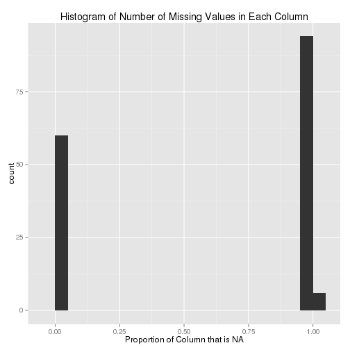

```r
qplot(colSums(is.na(training))/nrow(training), geom = "histogram", xlab = "Proportion of Column that is NA",
    main = "Histogram of Number of Missing Values in Each Column", binwidth = 0.05)
```

I then focus on the classe variable, which indicates the method used for the barbell lift. The most common value is A, but there are plenty of observations from each category to build a model.

```r
table(training$classe)
```

```
##
##    A    B    C    D    E
## 5580 3797 3422 3216 3607
```

There are too many variables to feasibly plot each against classe. Instead, to visualize classe's relationship with the independent variables, I performed Principle Component Analysis to reduce the dataset to two components. These components capture approximately 30% of the variance, so while important, this does not provide a comprehensive picture of the data. Below, I plot these components and use color to show the classe variable.

```r
training <- training[, (colSums(is.na(training))/nrow(training)) < 0.9]
preProc0 <- preProcess(subset(training, select = -classe), method = "pca", thresh = 0.3)
preProc0
```

```
## Created from 19622 samples and 59 variables
##
## Pre-processing:
##   - centered (56)
##   - principal component signal extraction (56)
##   - scaled (56)
##
## PCA needed 2 components to capture 30 percent of the variance
```

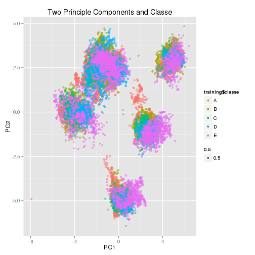

```r
twocomponents <- predict(preProc0, training)
training <- read.csv("trainingproject", na.strings = c("", "NA", "#DIV/0!"))
qplot(twocomponents$PC1, twocomponents$PC2, color = training$classe, alpha = 0.5,
    xlab = "PC1", ylab = "PC2", main = "Two Principle Components and Classe")
```

There is some amount of separation between the methods of performing lifts on these components (the region of red in between the four more densely populated regions for instance) but there is also considerable overlap. This suggests that using just these two components will likely not produce a highly accurate model, so a more complex model will be necessasry.